# STAT5003: Final Report

## Multinomial Logistic Regression

Logistic Regression is a supervised learning algorithm widely used for classification problems. It calculates the probability that an observation belongs to a particular class through a logistic (sigmoid) function applied to a linear combination of predictors. In this study, the model is used to predict crash severity levels—Non-casualty, Minor Injury, Moderate Injury, Serious Injury, and Fatal—based on environmental, temporal, vehicular, and enforcement-related factors.

Because the outcome variable is categorical with ordered severity levels, a multinomial logistic regression was applied. This approach estimates the probability of each crash belonging to one of several severity categories by modelling the log-odds of outcomes as a function of the predictors. A key benefit of logistic regression is that it provides interpretable coefficients showing how each factor influences the likelihood of more severe crashes, making it ideal for policy and safety applications where transparency and explainability are important. The pre-processing is extremely similar to what has been done previously, with the key difference being that we used one-hot encoding rather than dummy coding of categorical variables as this enables better performance with the engine used. The below code is commented to explain the process of pre-processing, model creation, and training.

```r
set.seed(5003)

crash_model_data_LR <- crash_data_SVC %>%
  dplyr::select(-`No. of traffic units involved`, -`No. killed`,
                -`No. seriously injured`, -`No. moderately injured`,
                -`No. minor-other injured`, -`Crash ID`)

selected_vars <- c(
  "month_sin", "day_sin", "hour_sin", "School zone active",
  "Weather", "Street lighting", "Natural lighting", "Speed limit", "Street type",
  "Type of location", "Urbanisation", "Alignment", "Road surface", "Surface condition",
  "Signals operation", "Other traffic control", "RUM - description",
  "DCA - description", "First impact type", "Key TU type", "Other TU type",
  "nearest_fixed_km", "nearest_redlight_km"
)

lr_data <- crash_model_data_LR %>%
  dplyr::select(dplyr::all_of(selected_vars), `Degree of crash - detailed`)

lr_split <- initial_split(lr_data, prop = 0.65, strata = `Degree of crash - detailed`)
lr.train <- training(lr_split) # 49526 obs
lr.test  <- testing(lr_split) # 26671 obs

lr_recipe <- recipe(`Degree of crash - detailed` ~ ., data = lr.train) %>%
  # Handle missing values for numeric predictors (impute with median)
  step_impute_median(all_numeric_predictors()) %>% # All remaining missing data is MAR or MCAR.
  # Handle missing values for categorical predictors (impute with mode)
  step_unknown(all_nominal_predictors(), new_level = "unknown") %>%

  # Handle values that appear in CV test folds but not training folds
  step_novel(all_nominal_predictors(), new_level = "unseen") %>%
  # Reduce high-cardinality categoricals
  step_other(all_nominal_predictors(), threshold = 0.01) %>%

  # Create dummy variables for all categorical predictors
  step_dummy(all_nominal_predictors(), one_hot = TRUE) %>% # One-hot better for glmnet

  # Because we have severely imbalanced classes
  themis::step_downsample(`Degree of crash - detailed`, under_ratio = 1.5, seed = 5003, skip = TRUE) %>% # Can change skip = FALSE once hyperparameter tuning is complete to create a balanced model.

  step_lincomb(all_predictors()) %>%
  step_zv(all_predictors())

# Multinomial logistic regression with tunable penalty
multinom_spec <- multinom_reg(penalty = tune(), mixture = tune()) %>%
  set_engine("glmnet", standardize = TRUE) %>%
  set_mode("classification")

# Create workflow
log_wf <- workflow() %>%
  add_recipe(lr_recipe) %>%
  add_model(multinom_spec)

# Cross-validation with stratification
crash_folds <- vfold_cv(lr.train, v = 5, strata = `Degree of crash - detailed`)

# Tune - grid for penalty parameter
multinom_grid <- crossing(penalty = 10^c(-3,-2,-1),
                          mixture = seq(0, 1, by = 0.5))

lf_res <- log_wf %>%
  tune_grid(
    resamples = crash_folds,
    grid = multinom_grid,
    metrics = metric_set(f_meas, bal_accuracy),
    control = control_grid(
      verbose = FALSE
    )
  )
```

**Click to see hyperparameter tuning**

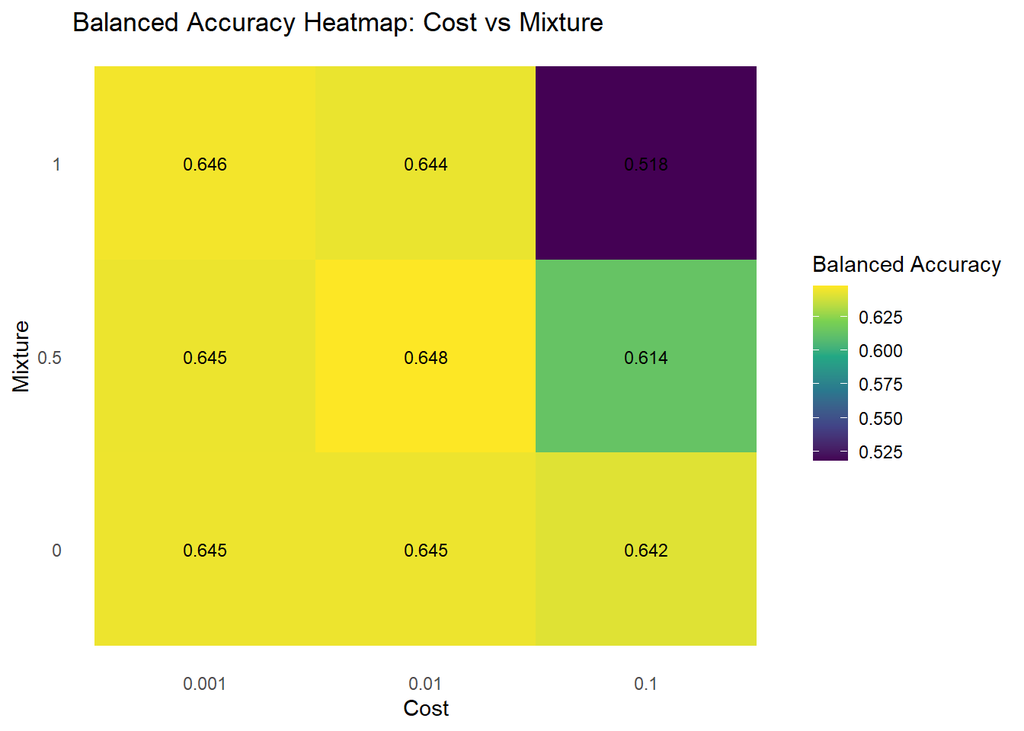

```r
# Visualisation
results <- lf_res %>% collect_metrics()
# Filter for metric of interest
results_filtered <- results %>%
  filter(.metric == "bal_accuracy")

# Create heatmap
ggplot(results_filtered, aes(x = factor(penalty), y = factor(mixture), fill = mean)) +
  geom_tile() +
  geom_text(aes(label = round(mean, 3)), size = 3, color = "black") +
  scale_fill_viridis_c(option = "viridis") +  # or "plasma", "magma"
  labs(
    title = "Balanced Accuracy Heatmap: Cost vs Mixture",
    x = "Cost",
    y = "Mixture",
    fill = "Balanced Accuracy"
  ) +
  theme_minimal() +
  theme(
    panel.grid = element_blank(),
    axis.text.x = element_text(angle = 0, hjust = 0.5)
  )
```

The following table provides the top 10 variables contributing to each type of crash.

```r
set.seed(5003)

best_multinom <- lf_res %>%
  select_best(metric = "bal_accuracy")

final_workflow <- log_wf %>%
  finalize_workflow(best_multinom)

final_fit <- final_workflow %>%
  fit(data = lr.train)

coef_tbl <- final_fit %>%
  extract_fit_parsnip() %>%
  tidy(penalty = best_multinom$penalty)

top10_per_class <- coef_tbl %>%
  filter(term != "(Intercept)") %>%
  mutate(abs_est = abs(estimate)) %>%
  group_by(class) %>%
  slice_max(order_by = abs_est, n = 10, with_ties = FALSE) %>%
  arrange(class, desc(abs_est)) %>%
  ungroup()
```

**Click to see top 10 features by class**

```r
top10_per_class
```

| class | term | estimate | penalty | abs_est |
| --- | --- | --- | --- | --- |
| Fatal | First impact type_Head.on | 1.0386202 | 0.01 | 1.0386202 |
| Fatal | Street lighting_Nil | 1.0384249 | 0.01 | 1.0384249 |
| Fatal | Street lighting_Off | 0.9768729 | 0.01 | 0.9768729 |
| Fatal | Street lighting_On | 0.7705307 | 0.01 | 0.7705307 |
| Fatal | First impact type_Vehicle...Pedestrian | 0.7491222 | 0.01 | 0.7491222 |
| Fatal | Other TU type_Large.rigid | 0.7437240 | 0.01 | 0.7437240 |
| Fatal | RUM - description_Struck.animal | -0.6929798 | 0.01 | 0.6929798 |
| Fatal | DCA - description_Right.turn | -0.6672931 | 0.01 | 0.6672931 |
| Fatal | Key TU type_Motorcycle | 0.5937428 | 0.01 | 0.5937428 |
| Fatal | Key TU type_Large.rigid | 0.5918992 | 0.01 | 0.5918992 |

[output cut: 40 more lines]

```r
# Test predictions and evaluation
test_predictions <- predict(final_fit, new_data = lr.test) %>%
  bind_cols(crash.test %>% dplyr::select(`Degree of crash - detailed`))

# Create confusion matrix
cm.multinom <- confusionMatrix(test_predictions$.pred_class,
                                test_predictions$`Degree of crash - detailed`)

# Convert to dataframe for plotting
conf_matrix_df <- as.data.frame(cm.multinom$table)

# Create heatmap
multinom_confusion <- ggplot(conf_matrix_df, aes(x = Reference, y = Prediction, fill = Freq)) +
  geom_tile(color = "white", linewidth = 0.5) +
  geom_text(aes(label = Freq), color = "black", size = 4) +
  scale_fill_gradient(low = "lightblue", high = "darkblue") +
  labs(title = "Multinomial Logistic Regression - Confusion Matrix",
       x = "Actual Crash Severity",
       y = "Predicted Crash Severity",
       fill = "Count") +
  theme_minimal() +
  theme(
    axis.text.x = element_text(angle = 30, hjust = 1),
    panel.grid = element_blank()
  )
```

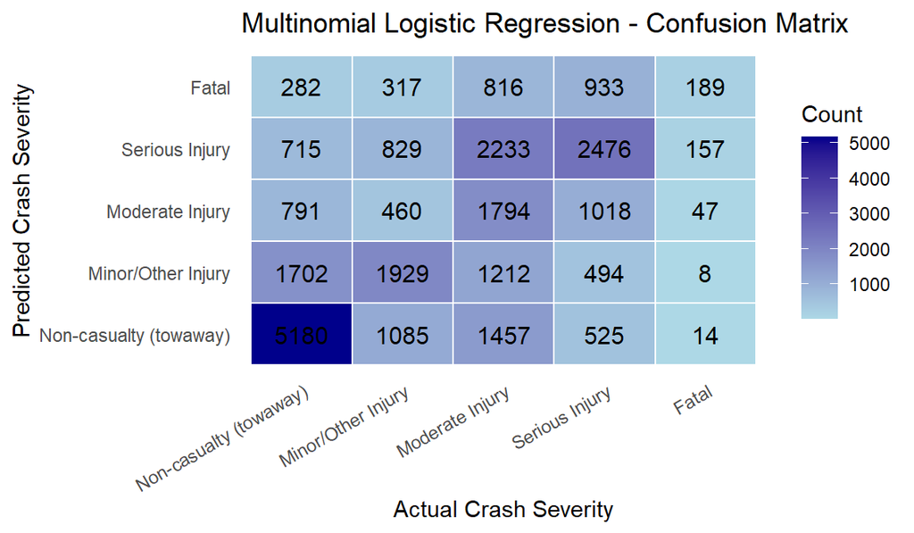

```r
print(multinom_confusion)
```

```r
rel.cm <- cm.multinom
f1 <- rel.cm$byClass[,"F1"] %>% mean(na.rm=TRUE)
bal_acc <- rel.cm$byClass[,"Balanced Accuracy"] %>% mean(na.rm=TRUE)
cat("F1 score:",f1, "\n")
```

```
## F1 score: 0.3707006
```

```r
cat("Balanced accuracy:",bal_acc)
```

```
## Balanced accuracy: 0.6441872
```

```r
results_df$Logistic_Regression <- c("Penalty: 0.01, Elastic Net Mixture: 0.5", round(f1,3), round(bal_acc, 3))
```

## Linear Discriminant Analysis (LDA)

We approached LDA in a distinct way to the other models. We assumed that LDA would perform poorly, as it relies on an assumption of normality that categorical predictors do not tend to follow. As such, we implemented Factor Analysis of Mixed Information (FAMD), a combination of Principal Components Analysis (PCA) and Multiple Correspondence Analysis (MCA) that allows for dimensionality reduction. We hoped that this change would allow LDA to perform better, while maintaining interpretability. The data cleaning and FAMD prediction process is visible below.

**Click to see details**

```r
# Extract FAMD components
famd_components <- famd_res$ind$coord

# Keep only the first 5 dimensions
famd_5 <- famd_components[, 1:5]

# Combine with the target variable
lda_final <- data.frame(severity = severity, famd_5)

# cat("Using first 5 FAMD dimensions:", ncol(lda_final) - 1, "components\n")

lda_model <- lda(severity ~ ., data = lda_final)
pred <- predict(lda_model)$class

# Safe comparison
accuracy <- mean(as.character(pred) == as.character(lda_final$severity))
conf_matrix <- table(True = lda_final$severity, Predicted = factor(pred, levels = levels(lda_final$severity)))

cat("LDA accuracy using first 5 FAMD dimensions:", round(accuracy * 100, 2), "%\n")
```

```
## LDA accuracy using first 5 FAMD dimensions: 37.24 %
```

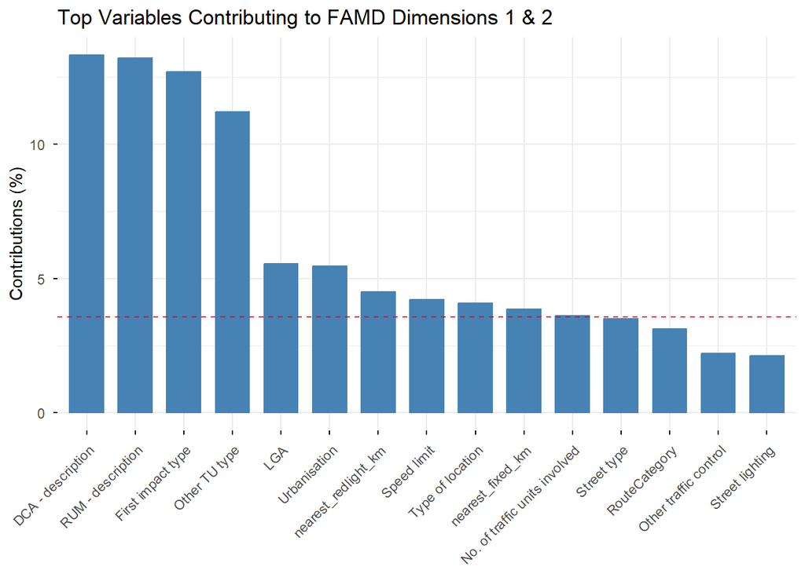

```r
# print(conf_matrix)

# Get LDA discriminant coordinates
lda_pred <- predict(lda_model)
lda_plot_data <- data.frame(lda_pred$x, severity = lda_final$severity)

# 2D plot
lda_plot_2d <- ggplot(lda_plot_data, aes(x = LD1, y = LD2, color = severity)) +
  geom_point(alpha = 0.6) +
  theme_minimal() +
  ggtitle("LDA projection: LD1 vs LD2 (by crash severity)") +
  labs(x = "Linear Discriminant 1", y = "Linear Discriminant 2") +
  theme(plot.title = element_text(hjust = 0.5))

# Compute centroids (mean coordinates for each class)
centroids <- lda_plot_data %>%
  group_by(severity) %>%
  summarise(LD1 = mean(LD1), LD2 = mean(LD2))

# Plot with ellipses, centroids, and labels
lda_plot_ld1_ld2 <- ggplot(lda_plot_data, aes(x = LD1, y = LD2, color = severity)) +
  stat_ellipse(level = 0.95, size = 1, alpha = 0.8) +
  geom_point(alpha = 0.3) +
  geom_point(data = centroids, aes(x = LD1, y = LD2, color = severity),
             shape = 4, size = 4, stroke = 1.5) +
  geom_text_repel(data = centroids, aes(label = severity, color = severity),
                  fontface = "bold", size = 4, show.legend = FALSE) +
  theme_minimal() +
  ggtitle("LDA Group Separation with 95% Confidence Ellipses and Centroid Labels") +
  labs(x = "Linear Discriminant 1", y = "Linear Discriminant 2") +
  theme(plot.title = element_text(hjust = 0.5))

lda_plot_dist <- ggplot(lda_plot_data, aes(x = LD1, fill = severity)) +
  geom_density(alpha = 0.5) +
  theme_minimal() +
  ggtitle("Distribution of LDA scores on LD1 by crash severity")

cm_df <- as.data.frame(conf_matrix)
lda_plot_cm <- ggplot(cm_df, aes(x = True, y = Predicted, fill = Freq)) +
  geom_tile() +
  geom_text(aes(label = Freq), color = "white") +
  scale_fill_gradient(low = "steelblue", high = "darkred") +
  theme_minimal() +
  ggtitle("Confusion Matrix Heatmap")


# Coefficients of linear discriminants
coef_df <- as.data.frame(lda_model$scaling)
coef_df$Variable <- rownames(coef_df)

# Plot variable loadings for first discriminant
lda_plot_var_contr <- ggplot(coef_df, aes(x = reorder(Variable, LD1), y = LD1)) +
  geom_bar(stat = "identity") +
  coord_flip() +
  theme_minimal() +
  ggtitle("Variable contribution to LD1")

# Compute absolute importance for LD1
coef_df <- coef_df %>%
  mutate(abs_LD1 = abs(LD1)) %>%
  arrange(desc(abs_LD1))

# Display top 15 influential variables for LD1
# head(coef_df, 15)

# Extract FAMD variable contributions
famd_contrib <- as.data.frame(famd_res$var$contrib)
famd_contrib$Variable <- rownames(famd_contrib)

# Get top FAMD dimensions used in LDA
top_dims <- coef_df %>%
  slice(1:5) %>%
  pull(Variable)

# Reshape FAMD contributions for filtering
library(tidyr)
famd_contrib_long <- famd_contrib %>%
  pivot_longer(cols = starts_with("Dim."), names_to = "Dim", values_to = "Contribution")

# Now safely filter and view
# famd_contrib_long %>%
#   filter(Dim %in% top_dims) %>%
#   arrange(desc(Contribution)) %>%
#   head(20)

lda_plot_contribute <- fviz_contrib(famd_res, "var", axes = 1:2, top = 15) +
  ggtitle("Top Variables Contributing to FAMD Dimensions 1 & 2")

print(lda_plot_contribute)
```

**Click to show confusion matrix**

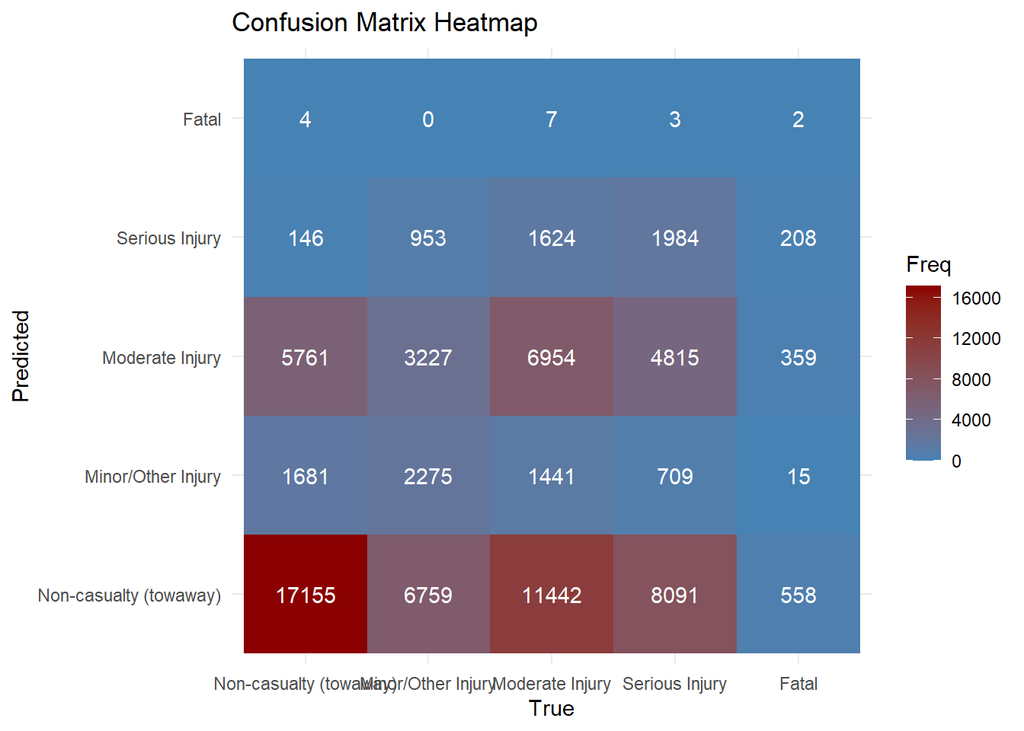

```r
print(lda_plot_cm)
```

```r
rel.cm <- confusionMatrix(conf_matrix)
f1 <- rel.cm$byClass[,"F1"] %>% mean(na.rm=TRUE)
bal_acc <- rel.cm$byClass[,"Balanced Accuracy"] %>% mean(na.rm=TRUE)
# cat("F1 score:",f1, "\n")
# cat("Balanced accuracy:",bal_acc)
results_df$LDA <- c("N/A", round(f1,3), round(bal_acc, 3))
```

Further visualisation revealed that there was substantial overlap between class centroids, indicating limited linear separability among the severity outcomes. This overlap suggests that the predictors contributing to crash severity interact in complex, non-linear ways that cannot be fully captured by a linear discriminant boundary.

**Click to see details**

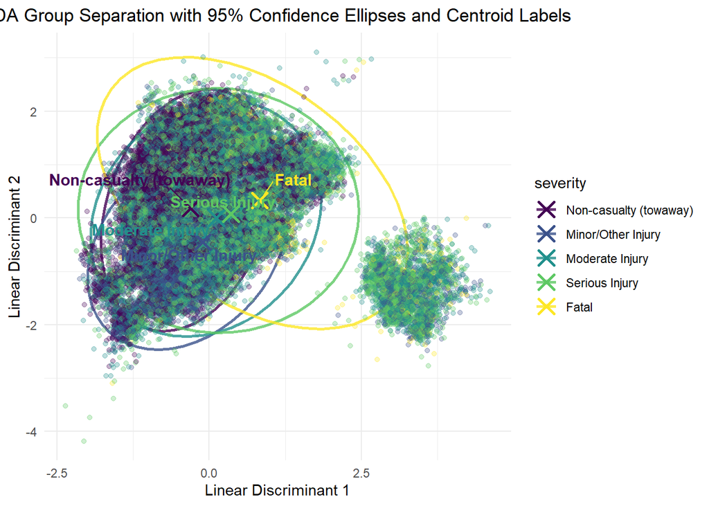

```r
print(lda_plot_ld1_ld2)
```

## Performance Evaluation

The summary table of best hyperparameters, along with F1 score and Balanced Accuracy on the test sample, are included below. Hyperparameters were optimised for balanced accuracy, although models tended not to perform significantly differently when optimised for F1 score. Comments are included, comparing each model.

Summary of Results and Hyperparameters for Each Model

[output not shown]

Overall, the best performing model by balanced accuracy was **logistic regression** (64.4%), while by F1 score it was the **Random Forest** model (0.374). However, most models achieved around 64% balanced accuracy, with only the KNN and LDA models performing more poorly. Minor tweaks (e.g., using log1p transformations instead of simple log transformation) lead to minor changes in performance, but with overall consistent trends.

The interpretability of models is also a consideration: Linear SVM, multinomial logistic regression and random forest all provide easy access to feature weights or relevance scores, allowing us to determine which factors may be more or less relevant. Additionally, looking at the top factors in the FAMD features provides us similar insight.

## Conclusion

Although no one model performed well enough for deployment, we observed that the most frequent confusion of our models was between semantically similar classes (i.e., Non-casualty vs Minor injury; Moderate vs Serious Injury). This suggests that models are making some progress towards accurately classifying the crashes, and are simply limited at a more nuanced level.

To improve predictive capacity, future research should also consider advanced resampling methods (e.g., SMOTE), explainable AI techniques (e.g., SHAP values for RF and SVM models), and integration of additional contextual data such as traffic flow, weather, and enforcement density. These enhancements would not only improve model accuracy but also strengthen the interpretive foundation necessary for evidence-based road safety interventions.

To conclude, although our models were limited to approximately 65% balanced accuracy, we believe that they answer our research question, suggesting that it is possible to classify the severity of crashes from road, weather, and related variables. This would enable data-driven decision making in terms of road safety measures, allowing organisational bodies to pre-emptively implement appropriate measures in high-risk areas.

## Appendix

### Extra SVM Plots and Models

**Note:** The polynomial degree 2 and 6 code is not evaluated to save on knitting time for the HTML file (as it already takes upwards of 45 minutes). The interested reader can change “eval” to TRUE in the code blocks below. The performance of the Deg 2 polynomial is ~57% balanced accuracy, while Deg 6 is ~63.9%. The polynomial degree 2 SVM cannot predict Fatal crashes at all.

Polynomial Degree 2:

```r
set.seed(5003)
# Polynomial Model
svm_poly <- svm_poly(cost = tune(), scale_factor = tune(), degree = tune()) %>%
  set_engine("kernlab") %>%
  set_mode("classification")

poly_grid <- crossing(cost = 10^c(-1,0,1),
                        scale_factor = c(0.0001,0.001, 1/150),
                        degree = c(2))

cell_folds <- vfold_cv(crash.train.subset, v = 5, strata = `Degree of crash - detailed`) # Training on subset in the hopes that it'll actually give me something

# svm_poly
# poly_grid

# Making the Workflow
poly_wf <- workflow() %>%
  add_recipe(crash_recipe) %>%
  add_model(svm_poly)

# Tuning the model
poly_res <- poly_wf %>%
  tune_grid(
    resamples = cell_folds,
    grid = poly_grid,
    metrics = metric_set(f_meas, bal_accuracy),
    control = control_grid(
      verbose = FALSE
    )
  )
```

```r
results <- poly_res %>% collect_metrics()
# Filter for metric of interest
results_filtered <- results %>%
  filter(.metric == "bal_accuracy")

# Create heatmap
ggplot(results_filtered, aes(x = factor(cost), y = factor(round(scale_factor,6)), fill = mean)) +
  geom_tile() +
  geom_text(aes(label = round(mean, 3)), size = 3, color = "black") +
  scale_fill_viridis_c(option = "viridis") +  # or "plasma", "magma"
  labs(
    title = "Balanced Accuracy Heatmap: C vs Scale Factor",
    x = "C",
    y = "Scale Factor",
    fill = "Balanced Accuracy"
  ) +
  theme_minimal() +
  theme(
    panel.grid = element_blank(),
    axis.text.x = element_text(angle = 0, hjust = 0.5)
  )
```

```r
set.seed(5003)
# Results list
result.list.poly_2 <- top_n_models(n = 1, wf = poly_wf, res = poly_res)

# result.list.poly_2[[1]]$confusion_matrix
```

```r
relevant.cm <- result.list.poly_2[[1]]$confusion_matrix
relevant.cm$table %>% as.data.frame %>%
  ggplot(aes(x = Reference, y = Prediction, fill = Freq)) +
    geom_tile() +
    geom_text(aes(label = Freq), color = "white", size = 4) +
    scale_fill_gradient(low = "lightgrey", high = "darkblue") +
    labs(title = "Polynomial 2 SVM - Confusion Matrix",
         x = "Actual Severity",
         y = "Predicted Severity") +
    theme_minimal() +
    theme(axis.text.x = element_text(angle = 30, hjust = 1))
```

Polynomial Degree 6:

```r
set.seed(5003)
# Polynomial Model
svm_poly_6 <- svm_poly(cost = tune(), scale_factor = tune(), degree = tune()) %>%
  set_engine("kernlab") %>%
  set_mode("classification")

poly_6_grid <- crossing(cost = 10^c(0,1),
                        scale_factor = c(0.0001, 0.001),
                        degree = c(6))

cell_folds <- vfold_cv(crash.train.subset, v = 5, strata = `Degree of crash - detailed`) # Training on subset in the hopes that it'll actually give me something

# svm_poly_6
# poly_6_grid

# Making the Workflow
poly_6_wf <- workflow() %>%
  add_recipe(crash_recipe) %>%
  add_model(svm_poly_6)

# Tuning the model
poly_6_res <- poly_6_wf %>%
  tune_grid(
    resamples = cell_folds,
    grid = poly_6_grid,
    metrics = metric_set(f_meas, bal_accuracy),
    control = control_grid(
      verbose = FALSE
    )
  )

# poly_6_res
```

```r
results <- poly_6_res %>% collect_metrics()
# Filter for metric of interest
results_filtered <- results %>%
  filter(.metric == "bal_accuracy")

# Create heatmap
ggplot(results_filtered, aes(x = factor(cost), y = factor(round(scale_factor,6)), fill = mean)) +
  geom_tile() +
  geom_text(aes(label = round(mean, 3)), size = 3, color = "black") +
  scale_fill_viridis_c(option = "viridis") +  # or "plasma", "magma"
  labs(
    title = "Balanced Accuracy Heatmap: C vs Scale Factor",
    x = "C",
    y = "Scale Factor",
    fill = "Balanced Accuracy"
  ) +
  theme_minimal() +
  theme(
    panel.grid = element_blank(),
    axis.text.x = element_text(angle = 0, hjust = 0.5)
  )
```

```r
set.seed(5003)
result.list.poly_6 <- top_n_models(n=1, wf = poly_6_wf, res = poly_6_res)
```

```r
relevant.cm <- result.list.poly_6[[1]]$confusion_matrix
relevant.cm$table %>% as.data.frame %>%
  ggplot(aes(x = Reference, y = Prediction, fill = Freq)) +
    geom_tile() +
    geom_text(aes(label = Freq), color = "white", size = 4) +
    scale_fill_gradient(low = "lightgrey", high = "darkblue") +
    labs(title = "Polynomial 6 SVM - Confusion Matrix",
         x = "Actual Severity",
         y = "Predicted Severity") +
    theme_minimal() +
    theme(axis.text.x = element_text(angle = 30, hjust = 1))
```

```r
rel.cm <- result.list.poly_6[[1]]$confusion_matrix
f1 <- rel.cm$byClass[,"F1"] %>% mean(na.rm=TRUE)
bal_acc <- rel.cm$byClass[,"Balanced Accuracy"] %>% mean(na.rm=TRUE)
cat("F1 score:",f1, "\n")
cat("Balanced accuracy:",bal_acc)
```

#### References

1. New South Wales Government, 2025–26 NSW Budget: Regional NSW (Glossy). Sydney, Australia: NSW Treasury, 2025. [Online]. Available: https://www.budget.nsw.gov.au/2025-26/budget-papers/regional- . [Accessed: Sep. 6, 2025].
2. Transport for New South Wales, “NSW Crash Data,” Transport for NSW Open Data Hub and Developer Portal, Mar. 23, 2018. [Online]. Available: https://opendata.transport.nsw.gov.au/dataset/nsw-crash-data
3. Transport for New South Wales, “NSW Speed Cameras,” Transport for NSW Open Data Hub and Developer Portal, Sep. 15, 2020. [Online]. Available: https://opendata.transport.nsw.gov.au/dataset/nsw-speed-cameras . [Accessed: Aug. 21, 2023].
4. Transport New South Wales, “Classified Roads Schedule” Transport Asset Planning and Assurance, Feb. 2023. [Online]. Available: https://www.transport.nsw.gov.au/system/files/media/documents/2023/classified-roads-schedule.pdf. [Accessed: Sep. 15, 2025]